# Lecture 12: Competing Risks I

STA310 Survival Analysis · Collett Chapter 12 (sections 12.1–12.3, Example 12.7)

2026-10-06

## Today

1. What are competing risks?
2. Why 1 − KM is biased
3. Data set-up in R
4. Cause-specific hazards and the cumulative incidence function
5. Aalen–Johansen estimation and plots
6. Comparing groups: Gray’s test, cause-specific log-rank
7. Probability versus rate

**Learning goals**

You can

- recognise a competing risks situation
- explain why 1 − KM overestimates the risk
- estimate and plot cumulative incidence functions in R
- compare CIFs between groups
- distinguish “probability” (CIF) from “rate” (cause-specific hazard)

# Concepts

## Motivation: more than one way for the story to end

Standard survival analysis: one event, everything else is (non-informative) censoring.

Often, several **different** endpoints are possible, and the first one that occurs **prevents** (or changes the meaning of) the others:

- Death from cancer vs. death from other causes
- Graft failure from rejection, thrombosis, recurrent disease, other causes (and death with a functioning graft)
- Liver transplant vs. death without transplant (e.g. in a trial of a drug for liver disease)
- Progression of a pre-malignant condition vs. death before progression

**Collett 12.1**

“A competing risk prevents the occurrence of an event of particular interest.” Each individual contributes a pair $(T, C)$: time and **cause** $C \in \{0, 1, \dots, m\}$, where $0$ = censored.

## Competing risks as a diagram

```
flowchart LR
  A["Event-free<br/>(at time 0)"] -->|"h1(t)"| B["Event 1<br/>(of interest)"]
  A -->|"h2(t)"| C["Event 2<br/>(competing)"]
  A -->|"hm(t)"| D["Event m"]
```

```
flowchart LR
  A["Event-free<br/>(at time 0)"] -->|"h1(t)"| B["Event 1<br/>(of interest)"]
  A -->|"h2(t)"| C["Event 2<br/>(competing)"]
  A -->|"hm(t)"| D["Event m"]
```

- Only **one** transition is observed per person: the first one
- Each arrow has its own **cause-specific hazard** $h_k(t)$
- After a competing event, the event of interest can no longer happen (death) or is no longer comparable (e.g. a transplant)

## Example 1: liver transplant recipients

1761 adult first liver transplants (2000–2010). Time to graft failure; cause `cof`: 0 = functioning graft (censored), 1 = rejection, 2 = thrombosis, 3 = recurrent disease, 4 = other.

```r
table(liver$cause)
```

```
         censored         rejection        thrombosis recurrent disease
             1501                29                73                42
            other
              116
```

Only 260 (15%) fail. In these data, patients who **die with a functioning graft** (211 according to Collett) are recorded as censored (`cof = 0`) at their time of death. Graft failure CIFs therefore treat death with a functioning graft as **censoring**, not as a competing event. Death is a competing event for graft failure, but it is not modelled as one here.

```r
liver |> count(disease, cause) |> pivot_wider(names_from = cause, values_from = n)
```

```
# A tibble: 3 × 6
  disease censored rejection thrombosis `recurrent disease` other
  <fct>      <int>     <int>      <int>               <int> <int>
1 ALD          811        14         28                  20    60
2 PBC          406         7         25                   5    26
3 PSC          284         8         20                  17    30
```

## Example 2: MGUS (monoclonal gammopathy)

`survival::mgus2`: 1384 Mayo Clinic patients with monoclonal gammopathy of undetermined significance (MGUS). It can progress to a plasma cell malignancy (myeloma, lymphoma, amyloidosis …). Patients are mostly elderly, so many die first.

From `?mgus2`: `ptime` = time to progression **or last contact**, `pstat` = progression (1/0), `futime` = time to death or last contact, `death` = death (1/0). Time in months.

```r
mgus2 |> select(id, age, sex, ptime, pstat, futime, death) |> head(4)
```

```
  id age sex ptime pstat futime death
1  1  88   F    30     0     30     1
2  2  78   F    25     0     25     1
3  3  94   M    46     0     46     1
4  4  68   M    92     0     92     1
```

```r
with(mgus2, table(pstat, death))
```

```
     death
pstat   0   1
    0 409 860
    1  12 103
```

## Building the event variable for MGUS

Time to **first** event: progression if it occurred, otherwise death or censoring.

```r
# Same set-up in Lecture 13. hgb (needed for the regression models there) is missing
# for some patients; we drop them here too, so that both lectures use identical data.
mgus <- mgus2 |>
  filter(!is.na(hgb)) |>
  mutate(etime = ifelse(pstat == 1, ptime, futime),
         event = factor(case_when(pstat == 1 ~ 1, death == 1 ~ 2, TRUE ~ 0),
                        levels = 0:2, labels = c("censored", "progression", "death")))
for (v in names(mgus)) attr(mgus[[v]], "label") <- NULL   # drop variable labels
table(mgus$event)
```

```
   censored progression       death
        402         114         855
```

13 patients with missing `hgb` are dropped, leaving 1371.

- `0` (first level, “censored”) must be censoring; `survfit` and `tidycmprsk` expect this
- Patients who progress and then die only count as **progression**: the first event ends the follow-up for this analysis

## Example 3: laboratory mice (Hoel 1972)

RFM male mice exposed to 300 rads of radiation; standard vs germ-free environment. Cause of death at autopsy: 1 = thymic lymphoma, 2 = reticulum cell sarcoma, 3 = other. **No censoring**: all mice die.

```r
with(mice, table(environment, cause))
```

```
           cause
environment censored thymic lymphoma reticulum cell sarcoma other
  Standard         0              22                     38    39
  Germ-free        0              29                     15    38
```

Question: does the environment change the risk of dying of each cause?

## Example 4: primary biliary cholangitis, transplant vs death

`survival::pbc`: Mayo Clinic trial of D-penicillamine. `status`: 0 = censored, 1 = liver transplant, 2 = dead. Transplant and death without transplant are competing events: whichever happens first ends the follow-up for the other.

```r
pbc2 <- pbc |> filter(!is.na(trt)) |>
  mutate(event = factor(status, 0:2, c("censored", "transplant", "death")))
table(pbc2$event)
```

```
  censored transplant      death
       168         19        125
```

# Why not just 1 − KM?

## The tempting approach

To get “the probability of event 1 by time $t$”: treat all other events as censored and compute $1 - \hat S_{KM}(t)$.

This estimates a **hypothetical** quantity: the risk if the competing events could not occur. Patients who died of another cause are treated as if they were still at risk of the event of interest (they are “censored”, i.e. assumed to behave like those still followed).

In reality they are **no longer at risk**. So 1 − KM is too large: it counts risk that belongs to people who will never experience event 1.

**Warning**

Collett 12.2.1: “there are pitfalls to using the Kaplan–Meier estimate … to summarise such data”. The bias grows with the frequency of competing events.

## Numerical demonstration: MGUS

```r
# naive: death treated as censoring
km <- survfit(Surv(etime, event == "progression") ~ 1, data = mgus)
# correct: Aalen-Johansen estimate of cumulative incidence
aj <- survfit(Surv(etime, event) ~ 1, data = mgus)
aj$states
```

```
[1] "(s0)"        "progression" "death"
```

```r
times <- c(120, 240, 360)
s_km <- summary(km, times = times)
s_aj <- summary(aj, times = times)
tibble(months = times,
       naive_1_minus_KM = round(1 - s_km$surv, 3),
       CIF_progression = round(s_aj$pstate[, 2], 3),
       CIF_death = round(s_aj$pstate[, 3], 3))
```

```
# A tibble: 3 × 4
  months naive_1_minus_KM CIF_progression CIF_death
   <dbl>            <dbl>           <dbl>     <dbl>
1    120            0.095           0.063     0.533
2    240            0.21            0.1       0.725
3    360            0.43            0.134     0.786
```

## Interpretation: MGUS

At 20 years (240 months): 1 − KM gives 0.21, the Aalen–Johansen CIF gives 0.1. That is an overestimate of about 111% in relative terms.

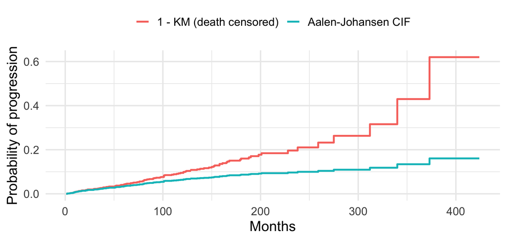

## Liver transplants: same message

Graft failure from rejection; all other failures (and censoring) as censoring versus proper CIF.

```r
km_l <- survfit(Surv(time, cause == "rejection") ~ 1, data = liver)
aj_l <- survfit(Surv(time, cause) ~ 1, data = liver)
tt <- c(365, 1095, 1825)
tibble(days = tt,
       naive = round(1 - summary(km_l, times = tt)$surv, 4),
       CIF = round(summary(aj_l, times = tt)$pstate[, 2], 4))
```

```
# A tibble: 3 × 3
   days  naive    CIF
  <dbl>  <dbl>  <dbl>
1   365 0.0098 0.0094
2  1095 0.0132 0.0125
3  1825 0.0159 0.0149
```

Here the other graft failure causes are rare (and death with a functioning graft is censored anyway), so the bias is small. **The bias depends on how common competing events are** and on the follow-up length. In the MGUS data (elderly, many deaths) it is large.

## Why does 1 − KM overshoot? A picture

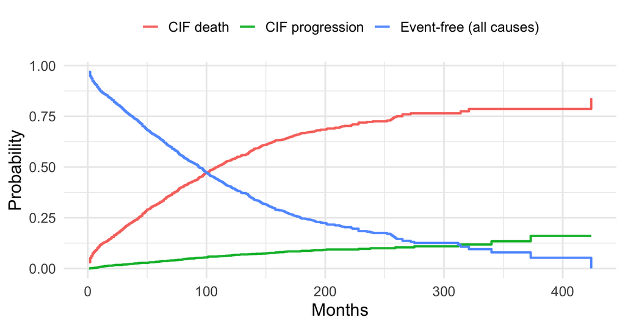

The three curves always add to 1. 1 − KM is not part of this system: it ignores the competing deaths.

# Setting up data

## Data layout

One row per person, with

- `time`: time to **first** event or censoring
- `event`: a **factor** whose first level is censoring, then the causes

```r
mgus |> select(id, etime, event) |> head(5)
```

```
  id etime event
1  1    30 death
2  2    25 death
3  3    46 death
4  4    92 death
5  5     8 death
```

```r
levels(mgus$event)
```

```
[1] "censored"    "progression" "death"
```

In `survival` (>= 3.0) `Surv(time, event_factor)` creates a **multi-state** survival object:

```r
Surv(mgus$etime, mgus$event)[1:5]
```

```
[1] 30:death 25:death 46:death 92:death  8:death
```

**Warning**

If `event` is numeric 0/1/2, `Surv(time, event)` assumes 0/1 or 1/2 coding for a **single** event. Use a factor!

# Hazards and cumulative incidence

## Cause-specific hazard

$$h_k(t) = \lim_{\Delta t \to 0} \frac{P(t \le T < t + \Delta t,\; C = k \mid T \ge t)}{\Delta t}$$

Instantaneous rate of an event of type $k$ among those **still event-free** at $t$ (not yet having had any event).

- Overall hazard: $h(t) = \sum_{k=1}^m h_k(t)$
- Cumulative cause-specific hazard $H_k(t) = \int_0^t h_k(u)\,du$
- Overall (event-free) survival:

$$S(t) = P(T > t) = \exp\Big\{-\sum_{k=1}^m H_k(t)\Big\}$$

Cause-specific hazards **are** estimable from the data: treat other causes as censored. That is legitimate for hazards (Collett 12.3.1), though not for probabilities.

## Cumulative incidence function (CIF)

$$\mathrm{CIF}_k(t) = P(T \le t,\; C = k) = \int_0^t S(u-)\, h_k(u)\, du$$

Reading the integrand: to have an event of type $k$ at time $u$, you must

1. be event-free just before $u$: probability $S(u-)$ (**all** causes), and
2. have an event of type $k$ at $u$: rate $h_k(u)$.

Properties:

- $\mathrm{CIF}_k(t)$ is increasing, starts at 0, and **plateaus below 1** (as $t\to\infty$ it reaches $P(C=k) < 1$ if other causes occur)
- $\sum_k \mathrm{CIF}_k(t) + S(t) = 1$ for all $t$
- It depends on **all** hazards, not only $h_k$

## The Aalen–Johansen estimator

With event times $t_{(j)}$, $d_{kj}$ events of type $k$, $d_j = \sum_k d_{kj}$, and $n_j$ at risk:

$$\hat h_k(t_{(j)}) = \frac{d_{kj}}{n_j}, \qquad \hat S(t_{(j)}) = \prod_{l \le j}\Big(1 - \frac{d_l}{n_l}\Big) \;(\text{ordinary KM, any event})$$

$$\widehat{\mathrm{CIF}}_k(t) = \sum_{j:\, t_{(j)} \le t} \hat S(t_{(j)}-)\,\frac{d_{kj}}{n_j}, \qquad \hat S(t_{(j)}-) = \hat S(t_{(j-1)})$$

- Without censoring: equals the observed proportion with cause $k$ by time $t$
- Implemented in `survfit()` (multi-state), `cmprsk::cuminc()` and `tidycmprsk::cuminc()`
- The estimates are the same; the packages differ in output and in extra tools

## Small worked example

Eight patients; times in months, cause 1 = progression, 2 = death, 0 = censored.

```r
toy <- tibble(time = c(2, 3, 3, 5, 6, 8, 9, 10), cause = c(1, 2, 0, 1, 2, 1, 0, 2))
toy
```

```
# A tibble: 8 × 2
   time cause
  <dbl> <dbl>
1     2     1
2     3     2
3     3     0
4     5     1
5     6     2
6     8     1
7     9     0
8    10     2
```

- $t=2$: $n=8$, $\hat S(0)=1$, $\widehat{\mathrm{CIF}}_1 = 1\cdot 1/8 = 0.125$; $\hat S(2) = 7/8$
- $t=3$: $n=7$, one death and one censored: $\widehat{\mathrm{CIF}}_2 = 0.875\cdot 1/7 = 0.125$; $\hat S(3) = 0.875 \cdot 6/7 = 0.75$ (censored tie counts as at risk)
- $t=5$: $n=5$, $\widehat{\mathrm{CIF}}_1 = 0.125 + 0.75 \cdot 1/5 = 0.275$

## Check the toy example in R

```r
f <- survfit(Surv(time, factor(cause, 0:2, c("censored", "progression", "death"))) ~ 1, data = toy)
tibble(time = f$time, n.risk = f$n.risk, event_free = round(f$pstate[, 1], 3),
       CIF_prog = round(f$pstate[, 2], 3), CIF_death = round(f$pstate[, 3], 3))
```

```
# A tibble: 7 × 5
   time n.risk[,"(s0)"] [,"progression"] event_free CIF_prog CIF_death
  <dbl>           <dbl>            <dbl>      <dbl>    <dbl>     <dbl>
1     2               8                0      0.875    0.125     0
2     3               7                0      0.75     0.125     0.125
3     5               5                0      0.6      0.275     0.125
4     6               4                0      0.45     0.275     0.275
5     8               3                0      0.3      0.425     0.275
6     9               2                0      0.3      0.425     0.275
7    10               1                0      0        0.425     0.575
# ℹ 1 more variable: n.risk[3] <dbl>
```

Each row: the three probabilities add to 1.

# Estimation in R

## Aalen–Johansen with `survfit()`

```r
aj <- survfit(Surv(etime, event) ~ 1, data = mgus)
aj
```

```
Call: survfit(formula = Surv(etime, event) ~ 1, data = mgus)

               n nevent     rmean se(rmean)*
(s0)        1371      0 128.48607   4.256397
progression 1371    114  37.71952   3.535934
death       1371    855 257.79442   5.040269
   *restricted mean time in state (max time = 424 )
```

```r
summary(aj, times = c(120, 240))
```

```
Call: survfit(formula = Surv(etime, event) ~ 1, data = mgus)

 time n.risk n.event Pr((s0)) Pr(progression) Pr(death)
  120    420     776    0.403          0.0635     0.533
  240     56     176    0.175          0.0998     0.725
```

`pstate` columns: event-free (`(s0)`), progression, death.

## `tidycmprsk::cuminc()`

```r
cif <- tidycmprsk::cuminc(Surv(etime, event) ~ 1, data = mgus)
cif
```

```
time   n.risk   estimate   std.error   95% CI
100    541      0.475      0.014       0.448, 0.502
200    123      0.684      0.015       0.655, 0.712
300    15       0.765      0.018       0.728, 0.797
400    1        0.786      0.022       0.740, 0.825
```

```
time   n.risk   estimate   std.error   95% CI
100    541      0.054      0.006       0.043, 0.068
200    123      0.092      0.009       0.076, 0.110
300    15       0.109      0.012       0.088, 0.134
400    1        0.161      0.032       0.104, 0.229
```

```r
tidycmprsk::tidy(cif, times = c(120, 240)) |>
  select(outcome, time, estimate, conf.low, conf.high) |>
  mutate(across(where(is.numeric), \(x) round(x, 3)))
```

```
# A tibble: 4 × 5
  outcome      time estimate conf.low conf.high
  <chr>       <dbl>    <dbl>    <dbl>     <dbl>
1 death         120    0.533    0.505     0.561
2 death         240    0.725    0.693     0.755
3 progression   120    0.063    0.051     0.078
4 progression   240    0.1      0.082     0.12
```

The `cuminc` object stores CIFs for **each** event type (not for censoring).

## Plotting CIFs with `ggsurvfit`

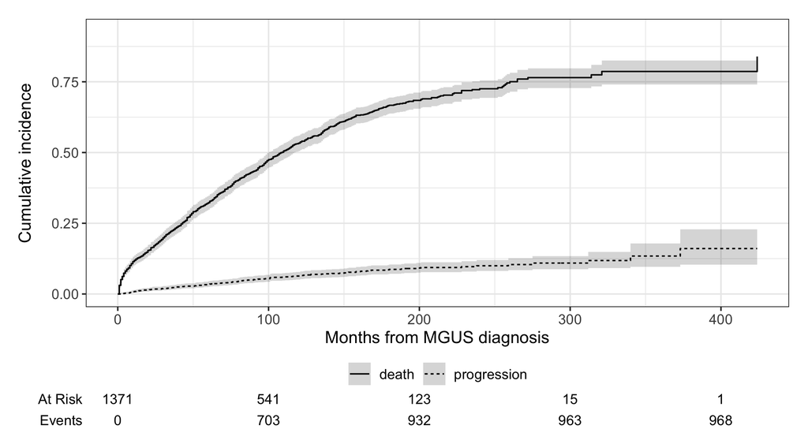

```r
cif |>
  ggcuminc(outcome = c("progression", "death")) +
  add_confidence_interval() +
  add_risktable() +
  labs(x = "Months from MGUS diagnosis", y = "Cumulative incidence")
```

## Stacked CIFs: where do the patients go?

The areas show how the population is distributed over the states over time. The top of the stack is the total risk of any event.

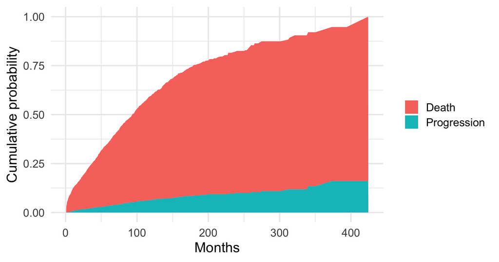

```r
tibble(time = aj$time, Progression = aj$pstate[, 2], Death = aj$pstate[, 3]) |>
  pivot_longer(-time, names_to = "state") |>
  mutate(state = factor(state, c("Death", "Progression"))) |>
  ggplot(aes(time, value, fill = state)) + geom_area() +
  labs(x = "Months", y = "Cumulative probability", fill = NULL)
```

The gap above the stack is event-free survival $\hat S(t)$.

## Interpretation: MGUS

- By 20 years 10% of patients are estimated to have progressed, but 73% have died without progression.
- At 20 years the CIF of death without progression is larger than the CIF of progression (see the plot above).
- Clinical message: in this elderly cohort death without progression is a major competing event, so reporting 1 − KM would exaggerate the progression risk.

The CIFs at a given time add up to the **total risk** of any first event, $1 - \hat S(t)$ (here at 240 months: 0.825).

## Mice: CIFs by environment

`cause` has no censored observations, but the factor still needs a first level for “censored” (empty here); otherwise the first cause would be taken as censoring.

```r
levels(mice$cause)
```

```
[1] "censored"               "thymic lymphoma"        "reticulum cell sarcoma"
[4] "other"
```

```r
ci_mice <- tidycmprsk::cuminc(Surv(time, cause) ~ environment, data = mice)
ci_mice
```

```
strata      time    n.risk   estimate   std.error   95% CI
Standard    200     89       0.061      0.024       0.025, 0.120
Standard    400     61       0.172      0.038       0.105, 0.253
Standard    600     32       0.303      0.047       0.215, 0.395
Standard    800     0        0.394      0.051       0.294, 0.492
Standard    1,000   0        0.394      0.051       0.294, 0.492
Germ-free   200     76       0.012      0.012       0.001, 0.059
Germ-free   400     59       0.049      0.024       0.016, 0.111
Germ-free   600     48       0.073      0.029       0.030, 0.143
Germ-free   800     20       0.268      0.050       0.177, 0.368
Germ-free   1,000   2        0.439      0.056       0.328, 0.545
```

```
strata      time    n.risk   estimate   std.error   95% CI
Standard    200     89       0.000      0.000       NA, NA
Standard    400     61       0.030      0.017       0.008, 0.079
Standard    600     32       0.152      0.036       0.089, 0.230
Standard    800     0        0.384      0.050       0.287, 0.480
Standard    1,000   0        0.384      0.050       0.287, 0.480
Germ-free   200     76       0.000      0.000       NA, NA
Germ-free   400     59       0.000      0.000       NA, NA
Germ-free   600     48       0.024      0.017       0.005, 0.077
Germ-free   800     20       0.159      0.041       0.089, 0.247
Germ-free   1,000   2        0.183      0.044       0.106, 0.276
```

```
strata      time    n.risk   estimate   std.error   95% CI
Standard    200     89       0.051      0.022       0.019, 0.107
Standard    400     61       0.182      0.039       0.113, 0.264
Standard    600     32       0.222      0.042       0.146, 0.309
Standard    800     0        0.222      0.042       0.146, 0.309
Standard    1,000   0        0.222      0.042       0.146, 0.309
Germ-free   200     76       0.061      0.027       0.022, 0.127
Germ-free   400     59       0.232      0.047       0.147, 0.328
Germ-free   600     48       0.317      0.052       0.219, 0.419
Germ-free   800     20       0.354      0.053       0.251, 0.457
Germ-free   1,000   2        0.354      0.053       0.251, 0.457
```

```
outcome                  statistic   df     p.value
thymic lymphoma          2.90        1.00   0.089
reticulum cell sarcoma   13.9        1.00   <0.001
other                    6.64        1.00   0.010
```

## Mice: all three causes

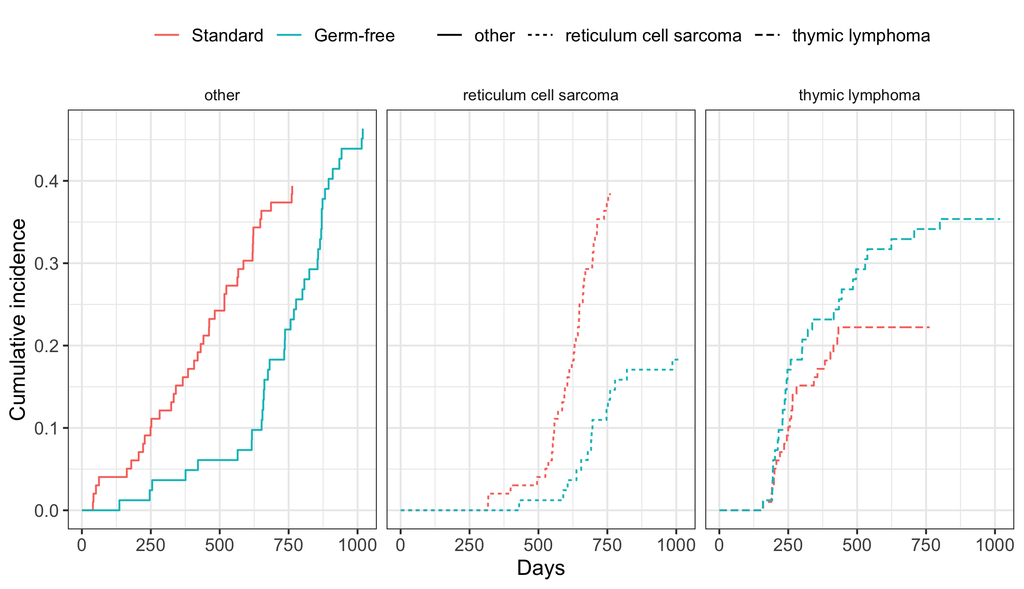

```r
ci_mice |>
  ggcuminc(outcome = c("thymic lymphoma", "reticulum cell sarcoma", "other")) +
  facet_wrap(~outcome) +
  labs(x = "Days", y = "Cumulative incidence") +
  theme(legend.position = "top")
```

## Interpretation: mice

```r
tm <- tidycmprsk::tidy(ci_mice, times = 800) |>
  select(outcome, strata, estimate) |>
  pivot_wider(names_from = strata, values_from = estimate) |>
  mutate(higher_in = ifelse(`Germ-free` > Standard, "Germ-free", "Standard"),
         across(where(is.numeric), \(x) round(x, 2)))
tm
```

```
# A tibble: 3 × 4
  outcome                Standard `Germ-free` higher_in
  <chr>                     <dbl>       <dbl> <chr>
1 other                      0.39        0.27 Standard
2 reticulum cell sarcoma     0.38        0.16 Standard
3 thymic lymphoma            0.22        0.35 Germ-free
```

Cumulative incidence at 800 days (no censoring, so these are crude proportions). The environment with the higher CIF is given in the last column: other (Standard); reticulum cell sarcoma (Standard); thymic lymphoma (Germ-free). Collett Example 12.7 describes the same pattern. Gray’s and the cause-specific log-rank tests (next section) quantify the evidence.

## Liver transplants: CIFs by cause

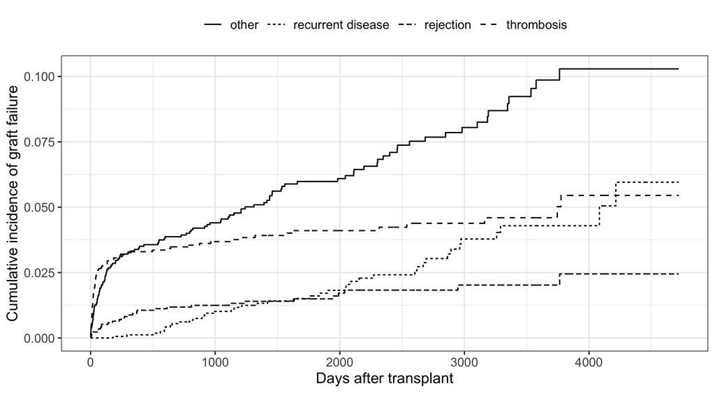

```r
ci_liv <- tidycmprsk::cuminc(Surv(time, cause) ~ 1, data = liver)
ci_liv |>
  ggcuminc(outcome = c("rejection", "thrombosis", "recurrent disease", "other")) +
  labs(x = "Days after transplant", y = "Cumulative incidence of graft failure") +
  theme(legend.position = "top")
```

```r
tidycmprsk::tidy(ci_liv, times = 3 * 365) |>
  select(outcome, estimate) |> mutate(estimate = round(estimate, 3))
```

```
# A tibble: 4 × 2
  outcome           estimate
  <chr>                <dbl>
1 other                0.045
2 recurrent disease    0.01
3 rejection            0.012
4 thrombosis           0.037
```

## Using `cmprsk::cuminc()` directly

```r
cm <- cmprsk::cuminc(ftime = liver$time, fstatus = liver$cof, group = liver$disease)
names(cm)
```

```
 [1] "ALD 1" "PBC 1" "PSC 1" "ALD 2" "PBC 2" "PSC 2" "ALD 3" "PBC 3" "PSC 3"
[10] "ALD 4" "PBC 4" "PSC 4" "Tests"
```

```r
cm$Tests
```

```
        stat          pv df
1  0.7967317 0.671416335  2
2  5.4050290 0.067036737  2
3 12.7911552 0.001668922  2
4  3.3836892 0.184179474  2
```

`cm` is a list: `"ALD 1"`, `"ALD 2"` … = group and cause; `time`, `est`, `var` for each. The `Tests` matrix is Gray’s test for each cause.

# Comparing groups

## Two questions, two tests

When comparing groups (treatment, disease, environment) we can ask about

1. **Probability**: does the cumulative incidence of cause $k$ differ? Gray’s test.
2. **Rate**: does the cause-specific hazard $h_k(t)$ differ? Cause-specific log-rank test (other causes censored).

They can give different answers. Gray’s test compares CIFs and so is also affected by group differences in the competing hazards.

## Gray’s test

Null hypothesis: $\mathrm{CIF}_k(t)$ equal in all groups, for a given cause $k$.

```r
cuminc_dis <- tidycmprsk::cuminc(Surv(time, cause) ~ disease, data = liver)
cuminc_dis |> tidycmprsk::glance()
```

```
# A tibble: 1 × 16
  outcome_1 statistic_1  df_1 p.value_1 outcome_2  statistic_2  df_2 p.value_2
  <chr>           <dbl> <dbl>     <dbl> <chr>            <dbl> <dbl>     <dbl>
1 rejection       0.797     2     0.671 thrombosis        5.41     2    0.0670
# ℹ 8 more variables: outcome_3 <chr>, statistic_3 <dbl>, df_3 <dbl>,
#   p.value_3 <dbl>, outcome_4 <chr>, statistic_4 <dbl>, df_4 <dbl>,
#   p.value_4 <dbl>
```

Gray’s test is a test of equality of the cumulative incidence functions between groups, performed for each cause separately. It can be seen as a weighted comparison of the **subdistribution** hazards. Stratification is possible, adjustment for covariates is not (see Lecture 13).

## Liver: CIFs by primary disease

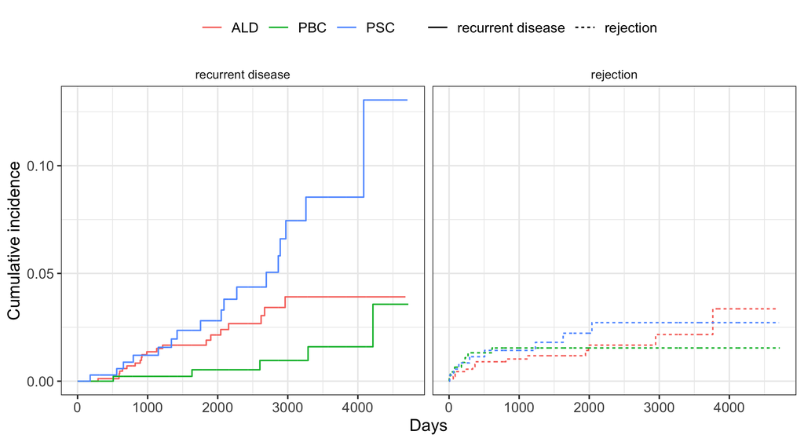

```r
cuminc_dis |>
  ggcuminc(outcome = c("rejection", "recurrent disease")) +
  facet_wrap(~outcome) +
  labs(x = "Days", y = "Cumulative incidence") + theme(legend.position = "top")
```

Gray’s test gives p = 0.67 for rejection (no difference at the 5% level) and p = 0.0017 for recurrent disease (a difference at the 5% level). Compare with the cause-specific log-rank tests on the next slide.

## Cause-specific log-rank tests

Treat other causes as censoring and use the ordinary log-rank test, once per cause:

```r
for (k in levels(liver$cause)[-1]) {
  lr <- survdiff(Surv(time, cause == k) ~ disease, data = liver)
  cat(sprintf("%-18s chi2 = %5.2f on %d df, p = %.4f\n", k, lr$chisq, length(lr$n) - 1,
              pchisq(lr$chisq, length(lr$n) - 1, lower.tail = FALSE)))
}
```

```
rejection          chi2 =  1.00 on 2 df, p = 0.6066
thrombosis         chi2 =  5.48 on 2 df, p = 0.0647
recurrent disease  chi2 = 14.06 on 2 df, p = 0.0009
other              chi2 =  3.75 on 2 df, p = 0.1532
```

Compare with Gray’s test. Agreement is common but not guaranteed.

## Mice: Gray’s test and cause-specific log-rank

```r
gm <- tidycmprsk::glance(ci_mice)
tibble(cause = c(gm$outcome_1, gm$outcome_2, gm$outcome_3),
       gray_p = c(gm$p.value_1, gm$p.value_2, gm$p.value_3))
```

```
# A tibble: 3 × 2
  cause                    gray_p
  <chr>                     <dbl>
1 thymic lymphoma        0.0888
2 reticulum cell sarcoma 0.000194
3 other                  0.00997
```

```r
for (k in levels(mice$cause)[-1]) {
  lr <- survdiff(Surv(time, cause == k) ~ environment, data = mice)
  cat(sprintf("%-24s log-rank p = %.2g\n", k, lr$pvalue))
}
```

```
thymic lymphoma          log-rank p = 0.28
reticulum cell sarcoma   log-rank p = 2e-11
other                    log-rank p = 3.6e-05
```

# Probability versus rate

## The key conceptual slide

|  | Cause-specific hazard $h_k(t)$ | Cumulative incidence $\mathrm{CIF}_k(t)$ |
| --- | --- | --- |
| Question | How fast do type-$k$ events happen **among those still event-free**? | What **fraction of all patients** will have a type-$k$ event by $t$? |
| Type | rate (per unit time) | probability |
| Depends on | cause $k$ only | **all** causes |
| Estimate | $d_{kj}/n_j$, other causes censored | Aalen–Johansen |
| Use | aetiology, biological effect | prediction, absolute risk, planning |

A treatment can reduce $h_1$ and still increase $\mathrm{CIF}_1$, if it also reduces the competing hazard $h_2$ (people live long enough to experience event 1).

## Worked numerical example

Constant hazards, $h_1 = 0.10$ per year in **both** populations. Population A: no competing risk ($h_2=0$). Population B: $h_2 = 0.40$.

$$\mathrm{CIF}_1(t) = \frac{h_1}{h_1 + h_2}\left(1 - e^{-(h_1 + h_2)t}\right)$$

```r
cif1 <- \(t, h1, h2) h1 / (h1 + h2) * (1 - exp(-(h1 + h2) * t))
tibble(year = c(1, 5, 10, 20),
       `A: h2 = 0` = cif1(year, 0.1, 0),
       `B: h2 = 0.4` = cif1(year, 0.1, 0.4)) |>
  mutate(across(-year, \(x) round(x, 3)))
```

```
# A tibble: 4 × 3
   year `A: h2 = 0` `B: h2 = 0.4`
  <dbl>       <dbl>         <dbl>
1     1       0.095         0.079
2     5       0.393         0.184
3    10       0.632         0.199
4    20       0.865         0.2
```

The rate of event 1 is identical, but the 10-year probability is 0.63 in A and only 0.2 in B. In the limit $t\to\infty$: $1$ vs $h_1/(h_1+h_2) = 0.2$.

## Same hazard, different CIF

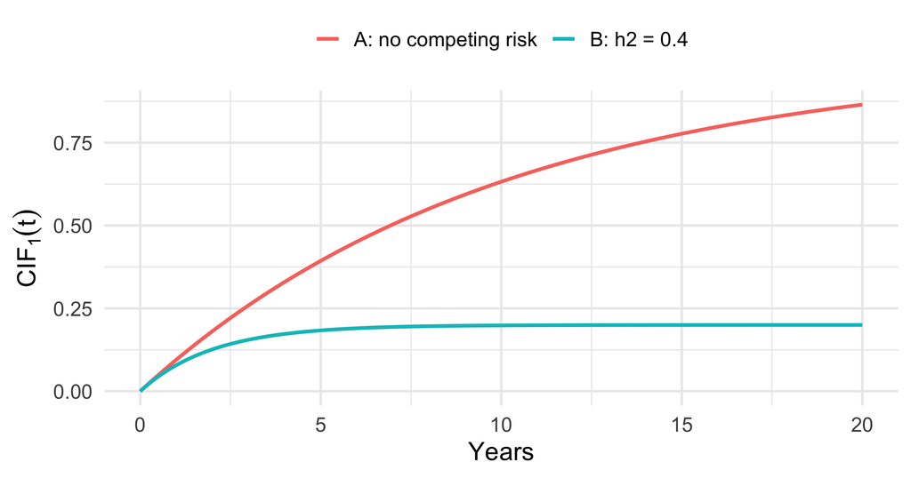

The CIF of event 1 depends on the competing hazard. Comparing two groups with different competing risks can reverse the ranking of CIFs even when $h_1$ is the same.

## Which one to report?

- **Aetiological question** (“does exposure X act on the biology of cause 1?”): cause-specific hazards
- **Prognosis/absolute risk** (“what is this patient’s chance of cause 1 by 5 years?”): CIF
- Best practice: report **both**, for every cause, with the CIFs plotted together
- Regression for each of them (cause-specific Cox, Fine–Gray) is the topic of **Lecture 13**

## Medical illustration: PBC, transplant vs death

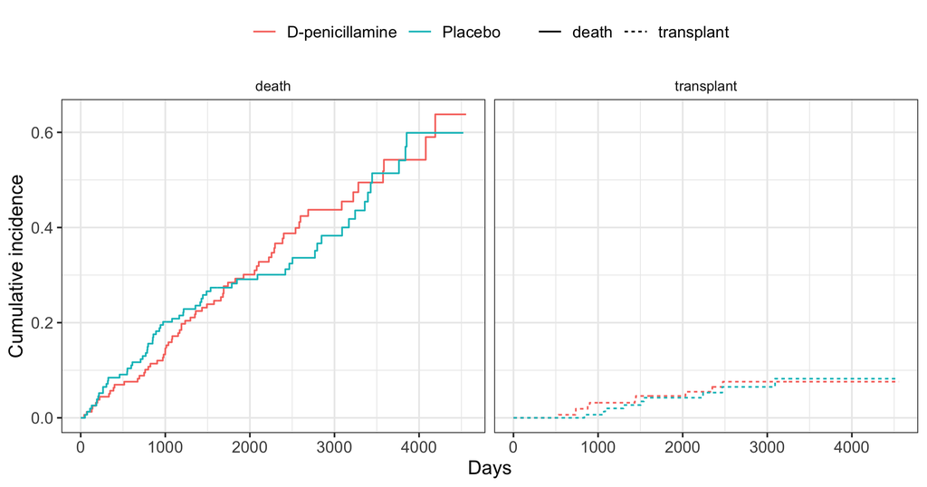

```r
ci_pbc <- tidycmprsk::cuminc(Surv(time, event) ~ trt, data = pbc2 |> mutate(trt = factor(trt, 1:2, c("D-penicillamine", "Placebo"))))
ci_pbc |>
  ggcuminc(outcome = c("transplant", "death")) + facet_wrap(~outcome) +
  labs(x = "Days", y = "Cumulative incidence") + theme(legend.position = "top")
```

```r
tidycmprsk::glance(ci_pbc)
```

```
# A tibble: 1 × 8
  outcome_1  statistic_1  df_1 p.value_1 outcome_2 statistic_2  df_2 p.value_2
  <chr>            <dbl> <dbl>     <dbl> <chr>           <dbl> <dbl>     <dbl>
1 transplant      0.0194     1     0.889 death          0.0666     1     0.796
```

Gray’s test for the treatment arms: p = 0.89 for transplant and p = 0.8 for death, i.e. no difference between the arms at the 5% level for either outcome. Transplant and death are competing: whichever occurs first ends the follow-up for the other.

## In-class exercise

Use the MGUS data (`mgus`, with `etime` and `event`) and a sex split.

1. Estimate CIFs of progression and death for men and women with `tidycmprsk::cuminc(Surv(etime, event) ~ sex, data = mgus)`.
2. Read off the CIF of progression at 10 years (120 months) in each sex.
3. Run Gray’s test (`glance()`). Which causes differ?
4. Run a cause-specific log-rank test for each cause and compare with Gray’s test.
5. Explain: why can the CIF of progression differ between the sexes even if the progression hazards are similar?

```r
# starting point
ci_sex <- tidycmprsk::cuminc(Surv(etime, event) ~ sex, data = mgus)
```

## Pitfalls

- Do not use 1 − KM with competing events censored to estimate the absolute risk
- Competing events must be defined **before** analysis: what counts as censoring (loss to follow-up) vs competing (death)
- Cause-specific censoring remains assumed to be independent of the event process
- CIFs of all causes should be displayed together; the sum is the total risk
- Death with a functioning graft in the liver data was recorded as censored (`cof = 0`): the graft failure CIFs treat it as censoring, not as a competing event

## Take-home messages

- **Competing risks**: an event that prevents the event of interest; ordinary censoring is wrong for them when we want probabilities
- 1 − KM overestimates risk; use the **cumulative incidence function** $\mathrm{CIF}_k(t)=\int_0^t S(u-)h_k(u)\,du$ (Aalen–Johansen)
- Data: time to first event plus a cause **factor** with censoring as the first level
- CIFs plus event-free survival add to 1
- Compare groups with **Gray’s test** (probabilities) or **cause-specific log-rank** (rates); report both
- A CIF depends on **all** cause-specific hazards

**Next lecture**: Competing risks II, regression (cause-specific Cox and Fine–Gray models)

**Reading**: Collett, Chapter 12 (Sections 12.1–12.3 and Example 12.7)